# Отчет по лабораторной работе №2

Простые сети в GNS3. Анализ трафика

Виноградова М.А

Российский университет дружбы народов, Москва, Россия

24 сентября 2026

# Информация

## Докладчик

- Виноградова Мария Андреевна
- студентка НПИбд-02-24
- номер студ. билета 1132240691
- Российский университет дружбы народов
- 1132240691@pfur.ru
- https://github.com/mavinogradova/study_2025-2026_os2

# Цель работы

Построение простейших моделей сети на базе коммутатора и маршрутизаторов FRR и VyOS в GNS3, анализ трафика посредством Wireshark.

# Задание

1. Построить в GNS3 топологию сети, состоящей из коммутатора Ethernet и двух оконечных устройств (персональных компьютеров). Задать оконечным устройствам IP-адреса в сети 192.168.1.0/24. Проверить связь.
2. Запустить на соединении между PC-1 и коммутатором анализатор трафика Wireshark. Проанализировать ARP-трафик, а также эхо-запросы в ICMP-, UDP- и TCP-режимах.
3. Построить в GNS3 топологию сети, состоящей из маршрутизатора FRR, коммутатора Ethernet и оконечного устройства. Задать оконечному устройству IP-адрес в сети 192.168.1.0/24, присвоить интерфейсу маршрутизатора адрес 192.168.1.1/24. Проверить связь.
4. Построить в GNS3 топологию сети, состоящей из маршрутизатора VyOS, коммутатора Ethernet и оконечного устройства. Задать оконечному устройству IP-адрес в сети 192.168.1.0/24, присвоить интерфейсу маршрутизатора адрес 192.168.1.1/24. Проверить связь.

# Выполнение лабораторной работы

# Моделирование простейшей сети на базе коммутатора в GNS3

## Запускаем GNS3 VM и GNS3. Создаём новый проект `prg-gns-01`.

[figure not shown]

Создание проекта prg-gns-01

## Размещаем коммутатор Ethernet и два VPCS, соединяем их.

[figure not shown]

Топология простейшей сети в GNS3

## Просматриваем синтаксис возможных для ввода команд VPCS.

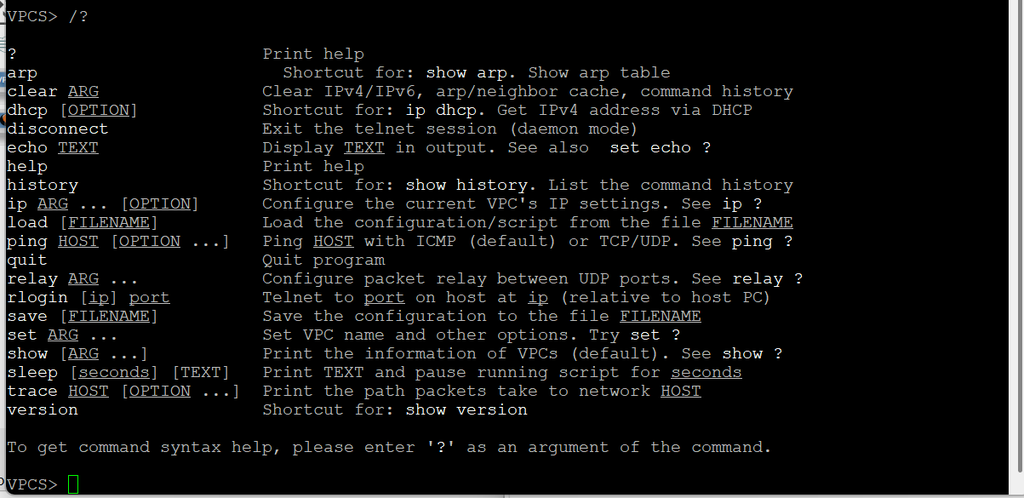

Просмотр синтаксиса возможных для ввода команд VPCS в GNS3

## Настраиваем IP-адресацию PC1.

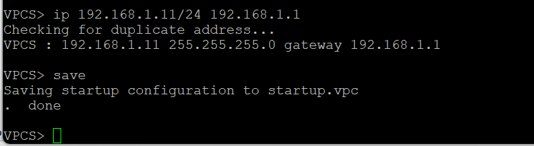

Настройка IP-адресации PC1

## Настраиваем IP-адресацию PC2.

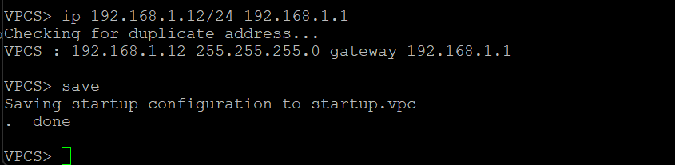

Настройка IP-адресации PC2

## Проверяем связь между PC1 и PC2.

[figure not shown]

Проверка связи между PC1 и PC2

# Анализ трафика в GNS3 посредством Wireshark

## Запускаем захват трафика на соединении PC1–коммутатор.

[figure not shown]

Запуск захвата трафика на соединении PC1–коммутатор

## Открывается окно Wireshark с захватом.

[figure not shown]

Окно Wireshark после запуска захвата

## Стартуем все узлы проекта.

[figure not shown]

Топология с запущенными узлами

## Анализируем информацию по протоколу ARP в Wireshark.

[figure not shown]

Информация по протоколу ARP в Wireshark

## Смотрим опции команды ping на PC-2.

[figure not shown]

Просмотр опций команды ping

## Делаем один эхо-запрос в ICMP-режиме к PC-1.

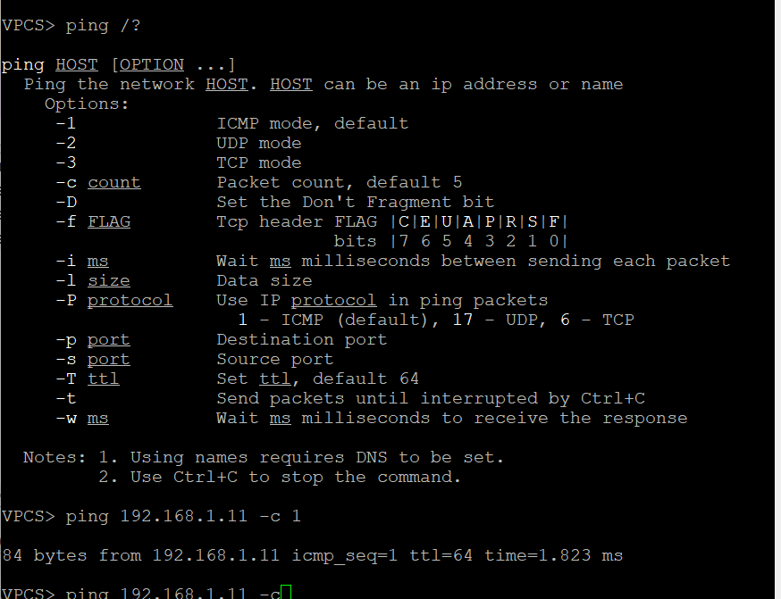

Один эхо-запрос в ICMP-режиме

## Анализируем ICMP-пакеты в Wireshark.

[figure not shown]

Анализ ICMP-пакетов в Wireshark

## Делаем один эхо-запрос в UDP-режиме к PC-1.

[figure not shown]

Один эхо-запрос в UDP-режиме

## Анализируем UDP-пакеты в Wireshark.

[figure not shown]

Анализ UDP-пакетов в Wireshark

## Делаем один эхо-запрос в TCP-режиме к PC-1.

[figure not shown]

Один эхо-запрос в TCP-режиме

## Анализируем TCP-пакеты в Wireshark.

[figure not shown]

Анализ TCP-пакетов в Wireshark

# Моделирование простейшей сети на базе маршрутизатора FRR в GNS3

## Создаём новый проект `pr01-mar`.

[figure not shown]

Создание проекта pr01-mar

## Размещаем VPCS, коммутатор Ethernet и маршрутизатор FRR.

[figure not shown]

Топология простейшей сети с маршрутизатором FRR в GNS3

## Настраиваем IP-адресацию PC1.

[figure not shown]

Настройка IP-адресации PC1

## Настраиваем IP-адресацию маршрутизатора FRR.

[figure not shown]

Настройка маршрутизатора FRR

## Проверяем конфигурацию маршрутизатора.

[figure not shown]

Проверка конфигурации FRR

## Проверяем подключение к FRR.

[figure not shown]

Проверка подключения к FRR

## Анализируем ICMP-пакеты между PC1 и FRR в Wireshark.

[figure not shown]

Анализ ICMP-пакетов между PC1 и FRR в Wireshark

# Моделирование простейшей сети на базе маршрутизатора VyOS в GNS3

## Создаём новый проект `pr01-VyOS`.

[figure not shown]

Создание проекта pr01-VyOS

## Размещаем VPCS, коммутатор Ethernet и маршрутизатор VyOS.

[figure not shown]

Топология простейшей сети с маршрутизатором VyOS в GNS3

## Настраиваем IP-адресацию PC1.

[figure not shown]

Настройка IP-адресации PC1

## Входим в VyOS, переходим в режим конфигурирования, меняем host-name.

[figure not shown]

Вход в VyOS и переход в режим конфигурирования

## Удаляем DHCP, задаём IP, выполняем compare / commit / save, смотрим интерфейсы.

[figure not shown]

Полная настройка маршрутизатора VyOS

## Проверяем подключение к VyOS.

[figure not shown]

Проверка подключения к VyOS